Libraries needed for data analysis are included below. Please unhash and install packages that are not already installed, otherwise the code will not run.

```r
#install.packages("tidyverse")
#install.packages("ggplot2")
#install.packages("ggforce")
#install.packages("mlr3verse")
#install.packages("GGally")
#install.packages("mlr3viz")
#install.packages("precrec")
#install.packages("ranger")
#install.packages("dplyr")
#install.packages("tinytex")

library("tidyverse")
library("ggplot2")
library("ggforce")
library("mlr3verse")
library("GGally")
library("mlr3viz")
library("precrec")
library("ranger")
library("dplyr")
library("tinytex")
```

Cancelling anything but essential messages, CV and nested resampling print out a lot and was annoying.

```r
lgr::get_logger("mlr3")$set_threshold("warn")
lgr::get_logger("bbotk")$set_threshold("warn")
```

The Chosen data set was the Bank personal loan upsell data set. With the aim to predict whether a customer can be “upsold” to a personal banking loan.

loading data from the link provided on learn:

```r
# creating a data frame
df <- readr::read_csv("https://www.maths.dur.ac.uk/users/hailiang.du/assignment_data/bank_personal_loan.csv")
```

First skim the data to get an overview of the data set:

```r
# Skimming
skimr::skim(df)
```

Data summary

| Name | df |
| --- | --- |
| Number of rows | 5000 |
| Number of columns | 13 |
| _______________________ |  |
| Column type frequency: |  |
| numeric | 13 |
| ________________________ |  |
| Group variables | None |

**Variable type: numeric**

| skim_variable | n_missing | complete_rate | mean | sd | p0 | p25 | p50 | p75 | p100 | hist |
| --- | --- | --- | --- | --- | --- | --- | --- | --- | --- | --- |
| Age | 0 | 1 | 45.34 | 11.46 | 23 | 35.0 | 45.0 | 55.0 | 67 | ▅▇▇▇▆ |
| Experience | 0 | 1 | 20.10 | 11.47 | -3 | 10.0 | 20.0 | 30.0 | 43 | ▅▇▇▇▅ |
| Income | 0 | 1 | 73.77 | 46.03 | 8 | 39.0 | 64.0 | 98.0 | 224 | ▇▇▃▂▁ |
| ZIP.Code | 0 | 1 | 93152.50 | 2121.85 | 9307 | 91911.0 | 93437.0 | 94608.0 | 96651 | ▁▁▁▁▇ |
| Family | 0 | 1 | 2.40 | 1.15 | 1 | 1.0 | 2.0 | 3.0 | 4 | ▇▇▁▆▆ |
| CCAvg | 0 | 1 | 1.94 | 1.75 | 0 | 0.7 | 1.5 | 2.5 | 10 | ▇▃▁▁▁ |
| Education | 0 | 1 | 1.88 | 0.84 | 1 | 1.0 | 2.0 | 3.0 | 3 | ▇▁▆▁▆ |
| Mortgage | 0 | 1 | 56.50 | 101.71 | 0 | 0.0 | 0.0 | 101.0 | 635 | ▇▂▁▁▁ |
| Personal.Loan | 0 | 1 | 0.10 | 0.29 | 0 | 0.0 | 0.0 | 0.0 | 1 | ▇▁▁▁▁ |
| Securities.Account | 0 | 1 | 0.10 | 0.31 | 0 | 0.0 | 0.0 | 0.0 | 1 | ▇▁▁▁▁ |
| CD.Account | 0 | 1 | 0.06 | 0.24 | 0 | 0.0 | 0.0 | 0.0 | 1 | ▇▁▁▁▁ |
| Online | 0 | 1 | 0.60 | 0.49 | 0 | 0.0 | 1.0 | 1.0 | 1 | ▆▁▁▁▇ |
| CreditCard | 0 | 1 | 0.29 | 0.46 | 0 | 0.0 | 0.0 | 1.0 | 1 | ▇▁▁▁▃ |

There is no missing data, which is good to know. All data is said to be numerical, which is technically correct. However, the data of 0,1,0 etc. is categorical, not continuous numerical. This needs to be taken into consideration.

Setting the seed for reproducible results

```r
set.seed(54)
options(mlr3.exec_random_seed = 54)
```

seeing what percentage of people accept the loan, this gives an idea of how balanced the data is:

```r
# summing personal loans coloum (0 or 1)
tot_loans <- sum(df$Personal.Loan)
len <- length(df$Personal.Loan)
# Dividing by lenght
(tot_loans/len)*100
```

```
## [1] 9.6
```

Only 9.6% of people accept the loan. This is a very small amount so the data is indeed unbalanced. Therefore it has to be taken into consideration when evaluating the model, and which metrics to judge/ compare models with. Model accuracy could be interpreted wrong, AUC maybe better.

looking at the relations between the continuous features with a pairs plot:

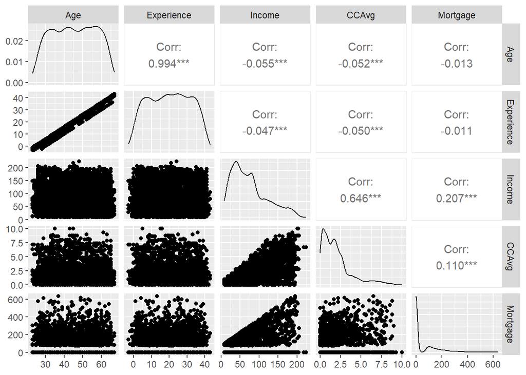

```r
# Pairs plot
ggpairs(df |> dplyr::select(Age, Experience, Income, CCAvg, Mortgage))
```

There is a nearly linear correlation between Age and Experience (0.994), so do not need both. Exclude “Experience” as there are negative values which is not right. These would need to be changed so more processing, easier to get rid of this column instead of “Age”.

Now to look at the relations between the discrete variables, so catagorical. Inspiration taken from the workshop.

```r
# Creating variable for ggplot
bank_discrete <- df |>
  dplyr::select(Personal.Loan, Education, Securities.Account, CD.Account, Online, CreditCard, Family) |>
  group_by(Personal.Loan, Education,  Securities.Account, CD.Account, Online, CreditCard, Family) |>
  summarize(value = n())
```

[output not shown]

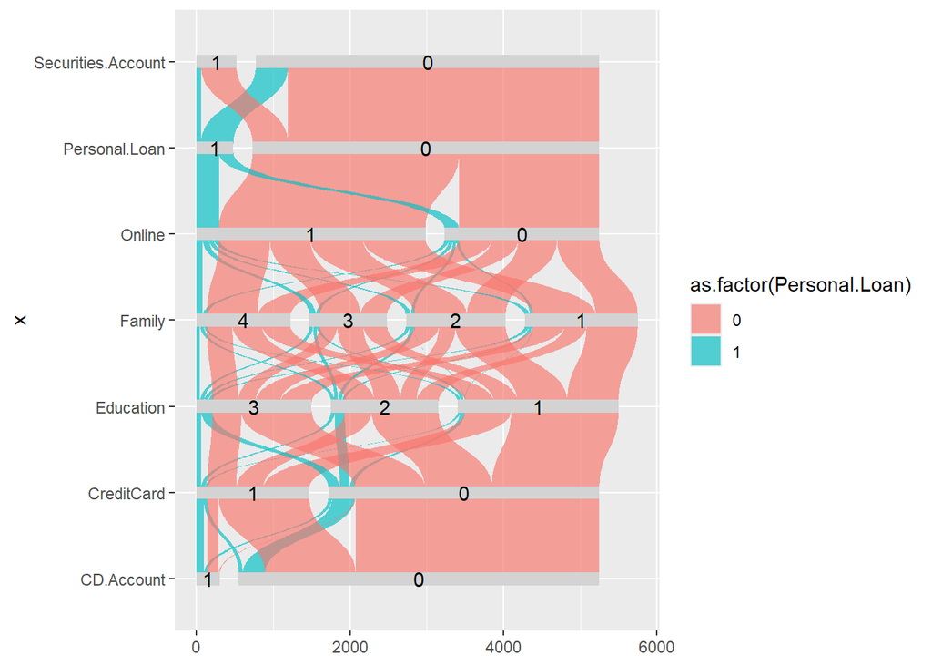

```r
# Plotting
ggplot(bank_discrete |> gather_set_data(x = c(1, 1:7)),
       aes(x = x, id = id, split = y, value = value)) +
  geom_parallel_sets(aes(fill = as.factor(Personal.Loan)),
                     axis.width = 0.1,
                     alpha = 0.66) +
  geom_parallel_sets_axes(axis.width = 0.15, fill = "lightgrey") +
  geom_parallel_sets_labels(angle = 0) +
  coord_flip()
```

Hard to see relations as a small fraction accept the personal loan. But between securities account, Personal loan and Online, there seems to be a group that follows this.

now get rid of data not needed (ZIP.Code as not in a format that is useful, does not say much):

```r
# deleting colums not needed
df <- df |>
  dplyr::select(-ZIP.Code, -Experience)
```

Make personal loan a factor and make education too. No need for the rest as the models (log regres and rand forest) are able to cope with this.

```r
# Making factors
df$Personal.Loan <- factor(df$Personal.Loan, levels = c(0, 1), labels = c("No", "Yes"))

df$Education = factor(df$Education, levels = c(1,2,3),
                       labels = c("Undergrad", "Graduate", "Advanced"))
```

Create a task for the model, makes life easier as in one object.

```r
# creating task object
task <- TaskClassif$new(
  id     = "personal_loan",
  backend = df,
  target  = "Personal.Loan",
  positive = "Yes"
)

# viewing task
task
```

[output not shown]

Splitting the data into test and training, not enough data for validate. Explained in report.

```r
split <- partition(task, ratio = 0.8)

# test and train objects
train_task <- task$clone()$filter(split$train)
test_task  <- task$clone()$filter(split$test)
```

Defining the models that are going to be tested - logistic regression and random forest:

```r
# logistic regression
learner_lr <- lrn("classif.log_reg", predict_type = "prob")

# pre processing pipeline
pipeline_lr <- po("scale") %>>%
               po("encode", method = "one-hot") %>>%
               po("learner", learner_lr)

# creating model
glrn_lr <- as_learner(pipeline_lr)

# -------------------------------------------------------------------
# random forest
learner_rf <- lrn("classif.ranger", predict_type = "prob")

# prepossessing pipeline
pipeline_rf <- po("encode", method = "one-hot") %>>%
               po("learner", learner_rf)

# model
glrn_rf <- as_learner(pipeline_rf)


# copies of the model
glrn_fresh_lr <- glrn_lr$clone()
glrn_fresh_rf <- glrn_rf$clone()

# final model to use
glrn_final <- glrn_rf$clone()
```

Just training on train data and testing on test data, to get a quick feel for the models and sanity check. Might be a bit unnecessary.

```r
# training log regression + predicting
glrn_lr$train(task, row_ids = split$train)
pred_lr <- glrn_lr$predict(task, row_ids = split$test)

# training random forest + prediciting
glrn_rf$train(task, row_ids = split$train)
pred_rf <- glrn_rf$predict(task, row_ids = split$test)

# Finiding evaluation metrics
pred_lr$score(msrs(c("classif.auc","classif.acc","classif.precision","classif.recall")))
```

```
##       classif.auc       classif.acc classif.precision    classif.recall
##         0.9728042         0.9590000         0.8202247         0.7448980
```

```r
pred_rf$score(msrs(c("classif.auc","classif.acc","classif.precision","classif.recall")))
```

```
##       classif.auc       classif.acc classif.precision    classif.recall
##         0.9987103         0.9910000         0.9890110         0.9183673
```

Random forest seems better here, but above method is not enough to be convincing. Cross validationis better to evaluate:

```r
# creating cross validation, 5 folds
cv <- rsmp("cv", folds = 5)
cv$instantiate(train_task)

# cv on log regression + random forest
rr_lr <- resample(train_task, glrn_fresh_lr, cv)
rr_rf <- resample(train_task, glrn_fresh_rf, cv)

# FInding metrics to compare
rr_lr$aggregate(msrs(c("classif.auc","classif.acc","classif.precision","classif.recall")))
```

```
##       classif.auc       classif.acc classif.precision    classif.recall
##         0.9571210         0.9577500         0.8717283         0.6579404
```

```r
rr_rf$aggregate(msrs(c("classif.auc","classif.acc","classif.precision","classif.recall")))
```

```
##       classif.auc       classif.acc classif.precision    classif.recall
##         0.9969571         0.9845000         0.9754573         0.8567683
```

Here random forest if defiantly better. Can futher improve by tuning hyper parameters. Ones to tune are: Hyper parameters - mtry = number of features at each split - min.node.size = min observations in leaf node - sample.fraction = proportion of data used per tree - num.trees = number of trees in forest Also now use nested resampling as can tune hyper-parameters with this.

This code takes a while to run.

```r
# creating random forest learner
learner <- lrn("classif.ranger",
               predict_type = "prob")

# pipeline
pipe <- po("encode", method = "one-hot") %>>%
        po("learner", learner)

# making model
model_pipe <- as_learner(pipe)

# vlaues of hyperparameters to try - the ranges
search_space <- ps(
  classif.ranger.mtry             = p_int(1, 10),
  classif.ranger.min.node.size    = p_int(1, 20),
  classif.ranger.sample.fraction  = p_dbl(0.5, 1),
  classif.ranger.num.trees        = p_int(200, 1000)
)

# random search for tuning hyper paramters - tuning object here
at <- auto_tuner(
  learner = model_pipe,
  resampling = rsmp("cv", folds = 3),
  measure = msr("classif.auc"),
  search_space = search_space,
  terminator = trm("evals", n_evals = 20),
  tuner = tnr("random_search")
)

# outer loop
outer_cv <- rsmp("cv", folds = 3)

# Nested resampling of random forest
rr <- resample(train_task, at, outer_cv, store_models = TRUE)

# Evaluation metrics
rr$aggregate(msrs(c(
  "classif.acc",
  "classif.auc",
  "classif.precision",
  "classif.recall",
  "classif.fbeta"
)))
```

```
##       classif.acc       classif.auc classif.precision    classif.recall
##         0.9844997         0.9977856         0.9733985         0.8614902
##     classif.fbeta
##         0.9139618
```

now to find the standard deviations and the confusion matrix.

```r
# creating scores object/variable
scores <- rr$score(msrs(c(
  "classif.auc",
  "classif.precision",
  "classif.recall",
  "classif.fbeta"
)))

# finding the standatd deviatio
scores |>
  summarise(
    auc_sd   = sd(classif.auc),
    precision_sd   = sd(classif.precision),
    recall_sd   = sd(classif.recall)
  )
```

```
##        auc_sd precision_sd  recall_sd
## 1 0.001009349  0.008530496 0.01126517
```

```r
# confusion matrix
rr_pred <- rr$prediction()
rr_pred$confusion
```

```
##         truth
## response  Yes   No
##      Yes  329    9
##      No    53 3609
```

Now the model is trained on the training data an evaluated finally on the unseen test data.

```r
# Now training the final model
at$train(train_task)
# and evaluating on unseen data
pred_test <- at$predict(test_task)

# finding metrics
pred_test$score(msrs(c(
  "classif.auc",
  "classif.acc",
  "classif.precision",
  "classif.recall",
  "classif.fbeta"
)))
```

```
##       classif.auc       classif.acc classif.precision    classif.recall
##         0.9986368         0.9910000         0.9784946         0.9285714
##     classif.fbeta
##         0.9528796
```

```r
pred_test$confusion
```

```
##         truth
## response Yes  No
##      Yes  91   2
##      No    7 900
```

plotting the ROC an precision recall curve

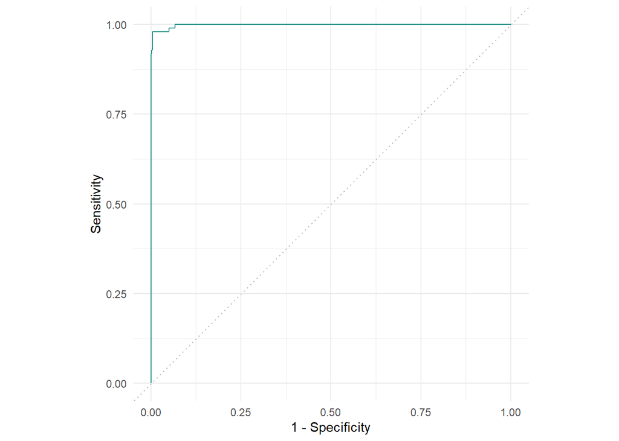

```r
# Plotting
autoplot(pred_test, type = "roc")
```

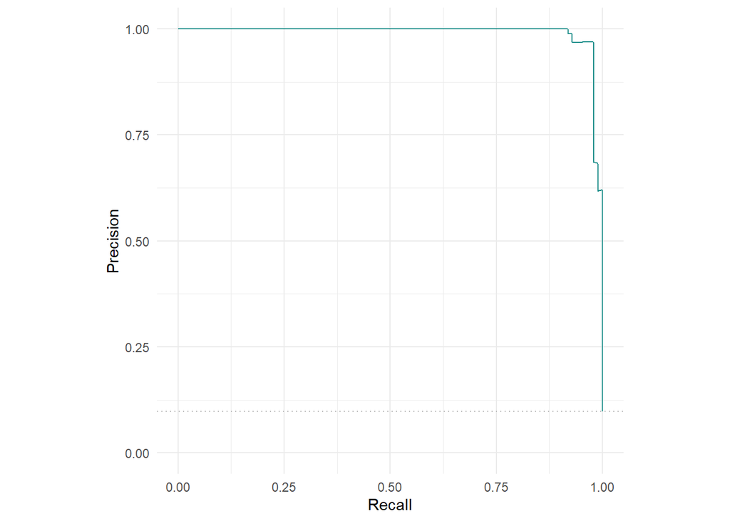

```r
autoplot(pred_test, type = "prc")
```

plotting the calibration plot.

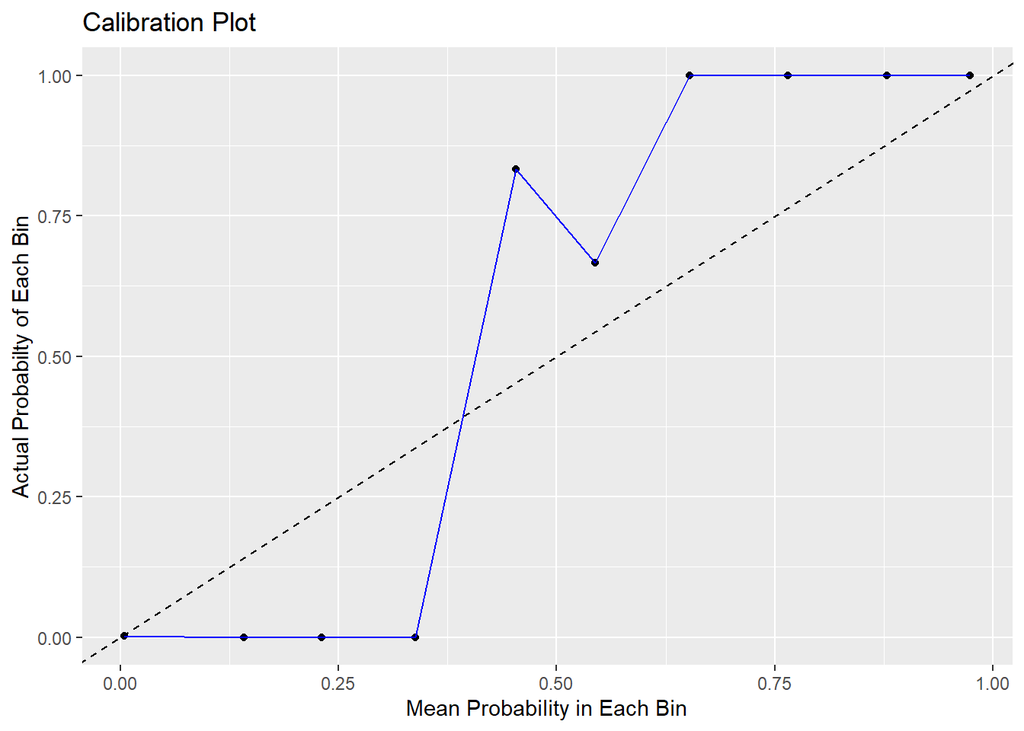

```r
# getting the data for the plot
calibration_data <- data.frame(
  predicted = pred_test$prob[, "Yes"],
  actual = as.numeric(pred_test$truth == "Yes")
)

# getting bins, grouping
calibration_data |>
  mutate(bin = cut(predicted, breaks = 10)) |>
  group_by(bin) |>
  summarise(
    mean_predicted = mean(predicted),
    actual_rate = mean(actual)
  ) |>
  # plotting the real and predicitons
  ggplot(aes(x = mean_predicted, y = actual_rate)) +
  geom_point() +
   geom_line(colour = "blue") +
  geom_abline(linetype = "dashed") +  # perfect calibration line
  labs(title = "Calibration Plot",
       x = "Mean Probability in Each Bin",
       y = "Actual Probabilty of Each Bin")
```